# Supplementary Material: Robustness Tests

Companion to *Strict vs. Multipurpose Conservation in Rural Madagascar*

Author

Published

March 30, 2026

# 1 Introduction

This supplementary material presents two robustness tests for the main results reported in the paper:

1. **OECD-modified equivalence scale income** (§2): The main paper uses total household income (`revtot`). Here we adjust for household composition using the OECD-modified equivalence scale ($1 + 0.5 \times (\text{additional adults}) + 0.3 \times \text{children}$, with children defined as members under 14). This addresses the concern that household size differences between treated and control groups could confound the estimated treatment effect.
2. **Levels-based gsynth** (§3): The main paper uses log-transformed income as the outcome. Here we re-estimate both models using income in levels (Malagasy Ariary) to assess whether the log transformation drives the results.

For each test, we re-estimate both the Ankarafantsika (strict) and Lac Alaotra (multipurpose) gsynth models using the same donor pool and estimation parameters as the main paper.

# 2 Robustness Test 1: OECD-Modified Equivalence Scale

## 2.1 Constructing the Equivalence Scale

The OECD-modified equivalence scale assigns a weight of 1 to the first household member, 0.5 to each additional member aged 14 or above, and 0.3 to each member under 14. We compute this from the individual-level member files (`res_m_a.dta` / `res_m.dta`), which record age (`m5`) for each household member.

Table 1: OECD-modified equivalence scale: summary statistics for Marovoay and Alaotra observatories

Household Composition (1999–2014)

OECD-modified equivalence scale: 1 + 0.5 × (adults − 1) + 0.3 × children

| Observatory | Mean equiv. scale | SD | Mean adults | Mean children | N obs. |
| --- | --- | --- | --- | --- | --- |
| Alaotra | 2.67 | 0.9 | 3.1 | 2 | 7612 |
| Marovoay | 2.67 | 1.0 | 3.1 | 2 | 7489 |

Table 2: OECD equivalence scale by treatment group in Marovoay, showing that east-bank (treated) households are slightly larger

Marovoay: Household Composition by Treatment Status

| group | period | Mean equiv. | SD | Mean HH size | N |
| --- | --- | --- | --- | --- | --- |
| East bank (treated) | Post-treatment | 2.70 | 1.01 | 5.3 | 2580 |
| West bank (control) | Post-treatment | 2.55 | 0.93 | 4.8 | 2835 |
| East bank (treated) | Pre-treatment | 2.80 | 1.07 | 5.6 | 1036 |
| West bank (control) | Pre-treatment | 2.79 | 1.07 | 5.5 | 1038 |

## 2.2 Equivalence-Adjusted Income Panels

We merge the equivalence scale onto the household income data and compute equivalised income as `revtot / oecd_equiv`.

## 2.3 gsynth Results: Equivalised Income

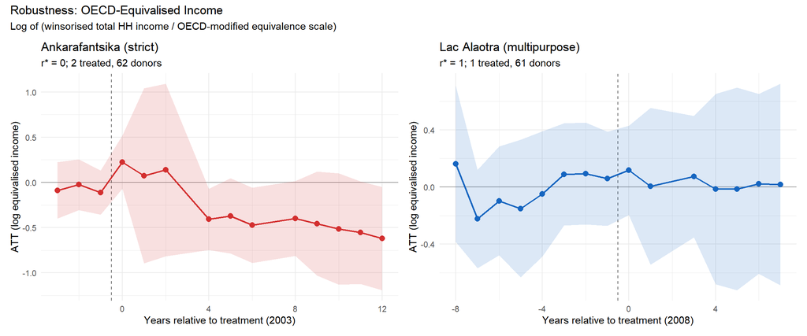

Figure 1: ATT paths using OECD-modified equivalised income. Left: Ankarafantsika (strict). Right: Lac Alaotra (multipurpose). Compare with Figures 7–8 of the main paper.

**Ankarafantsika (equivalised income).** The average post-treatment ATT is **-0.359 log points** (95%% CI: [-0.614, -0.104]; SE = 0.130; p = 0.006), corresponding to approximately **-30.1%%** in equivalised income. For comparison, the main paper’s baseline estimate (total household income) is -0.387 log points (-32.1%%). Adjusting for household composition **attenuates** the estimated effect, consistent with east-bank households being slightly larger than west-bank ones.

**Lac Alaotra (equivalised income).** The average post-treatment ATT is **0.015 log points** (95%% CI: [-0.303, 0.333]; SE = 0.162; p = 0.926), corresponding to approximately **+1.5%%** in equivalised income. As in the main specification, the confidence interval spans zero and the effect is **not statistically significant**.

# 3 Robustness Test 2: Income in Levels

The main paper uses log-transformed income to handle the right-skewed distribution and allow semi-elasticity interpretation. Here we re-estimate both gsynth models using winsorised income in levels (Malagasy Ariary, not deflated).

## 3.1 Panel Construction

Table 3: Income in levels: scale of the outcome variable across observatories (winsorised, thousands of Ariary)

Winsorised Total Household Income (thousands of Ariary)

1999–2014, all panel observations

| group | Mean income (k Ar) | Median | SD | N |
| --- | --- | --- | --- | --- |
| Alaotra (treated) | 1,648 | 979 | 1,858 | 7,613 |
| Donor pool | 1,154 | 745 | 1,272 | 48,052 |
| Marovoay East (treated) | 1,918 | 1,447 | 1,591 | 3,617 |
| Marovoay West (control) | 1,711 | 1,280 | 1,437 | 3,642 |

## 3.2 gsynth Results: Income in Levels

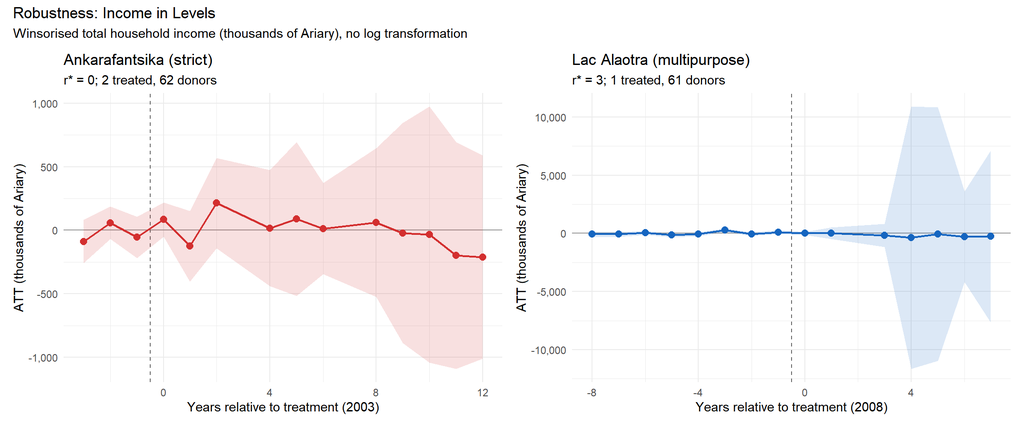

Figure 2: ATT paths using income in levels (winsorised, thousands of Ariary). Left: Ankarafantsika. Right: Lac Alaotra. The y-axis is in thousands of Ariary.

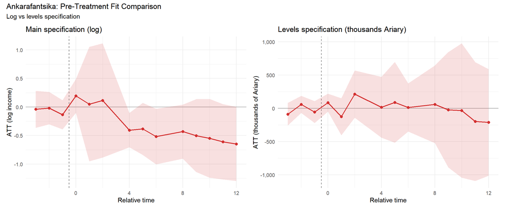

Figure 3: Pre-treatment trends comparison (Marovoay): log income (left) vs levels (right). The levels specification may show different pre-treatment fit if the income distribution is highly skewed.

**Ankarafantsika (levels).** The average ATT is **-20 thousand Ariary** (95%% CI: [-241, 202]; SE = 113; p = 0.863). This represents approximately **-1.6%%** of the pre-treatment mean income for east-bank households (1,192 thousand Ariary).

**Lac Alaotra (levels).** The average ATT is **-188 thousand Ariary** (95%% CI: [-3,070, 2,693]; SE = 1,470; p = 0.898). As in the main specification, the effect is **not statistically significant** at the 5%% level.

# 4 Summary of Robustness Tests

Table 4: Summary of all specifications: baseline (log total income), OECD-equivalised (log), and levels (Ariary)

Robustness Summary

Comparison across three income specifications

| PA | Specification | ATT | SE | 95% CI | p-value | r* (CV) | Unit |
| --- | --- | --- | --- | --- | --- | --- | --- |
| Baseline: log(total household income) |  |  |  |  |  |  |  |
| Ankarafantsika | Baseline: log(total income) | -0.387 | 0.137 | [-0.657, -0.118] | 0.005 | 0 | log points |
| Lac Alaotra | Baseline: log(total income) | -0.018 | 0.172 | [-0.355, 0.319] | 0.916 | 1 | log points |
| OECD-equivalised: log(income / equiv. scale) |  |  |  |  |  |  |  |
| Ankarafantsika | OECD-equivalised: log(income/equiv) | -0.359 | 0.130 | [-0.614, -0.104] | 0.006 | 0 | log points |
| Lac Alaotra | OECD-equivalised: log(income/equiv) | 0.015 | 0.162 | [-0.303, 0.333] | 0.926 | 1 | log points |
| Levels: income (Ariary) |  |  |  |  |  |  |  |
| Ankarafantsika | Levels: income (Ariary) | -19.500 | 112.849 | [-240.705, 201.656] | 0.863 | 0 | k Ariary |
| Lac Alaotra | Levels: income (Ariary) | -188.400 | 1469.952 | [-3069.495, 2692.61] | 0.898 | 3 | k Ariary |